# R Notebook

### Atribúty hits.home a hits.away

**charakteristika:** atribút obsahuje hodnoty počtu narazení domáceho a hosťujúceho tímu. Narazenia, resp. osobné súboje vznikajú počas hry a pripočítavajú sa na stranu tímu, ktorý narazenie inicioval. Preto sa hodnoty medzi súperiacimi tímami nemusia rovnať.

```r
summary(df$hits.home)
```

```
   Min. 1st Qu.  Median    Mean 3rd Qu.    Max.    NA's
   0.00   18.00   23.00   23.43   28.00   80.00       4
```

```r
summary(df$hits.away)
```

```
   Min. 1st Qu.  Median    Mean 3rd Qu.    Max.    NA's
   0.00   16.00   21.00   22.44   27.00   80.00       4
```

Zo zhrnutia môžeme vidieť, že hodnoty môžu byť pravdivé, resp. neobsahujú čísla, ktoré by logicky nemohli nastať. Taktiež vidíme, že v štyroch záznamoch nám chýbajú hodnoty tohoto atribútu.

```r
df[is.na(df$hits.home)]
```

| season | type | goals.away | goals.home | team_id.away | won.away | shots.away | hits.away | pim.away | powerPlayOpportunities.away | powerPlayGoals.away | faceOffWinPercentage.away | giveaways.away | takeaways.away | blocked.away | abbreviation.away | team_id.home | won.home | settled_in | shots.home | hits.home | pim.home | powerPlayOpportunities.home | powerPlayGoals.home | faceOffWinPercentage.home | giveaways.home | takeaways.home | blocked.home | abbreviation.home | save_percentage.home | … |
| --- | --- | --- | --- | --- | --- | --- | --- | --- | --- | --- | --- | --- | --- | --- | --- | --- | --- | --- | --- | --- | --- | --- | --- | --- | --- | --- | --- | --- | --- | --- |
| 20172018 | P | 0 | 0 | 28 | FALSE | NA | NA | NA | NA | NA | NA | NA | NA | NA | SJS | 24 | FALSE | tbc | NA | NA | NA | NA | NA | NA | NA | NA | NA | ANA | NA | … |
| 20172018 | P | 0 | 0 | 52 | FALSE | NA | NA | NA | NA | NA | NA | NA | NA | NA | WPG | 54 | FALSE | tbc | NA | NA | NA | NA | NA | NA | NA | NA | NA | VGK | NA | … |
| 20172018 | P | 0 | 0 | 54 | FALSE | NA | NA | NA | NA | NA | NA | NA | NA | NA | VGK | 52 | FALSE | tbc | NA | NA | NA | NA | NA | NA | NA | NA | NA | WPG | NA | … |
| 20162017 | P | 0 | 0 | 3 | FALSE | NA | NA | NA | NA | NA | NA | NA | NA | NA | NYR | 9 | FALSE | tbc | NA | NA | NA | NA | NA | NA | NA | NA | NA | OTT | NA | … |

```r
df[is.na(df$hits.away)]
```

| season | type | goals.away | goals.home | team_id.away | won.away | shots.away | hits.away | pim.away | powerPlayOpportunities.away | powerPlayGoals.away | faceOffWinPercentage.away | giveaways.away | takeaways.away | blocked.away | abbreviation.away | team_id.home | won.home | settled_in | shots.home | hits.home | pim.home | powerPlayOpportunities.home | powerPlayGoals.home | faceOffWinPercentage.home | giveaways.home | takeaways.home | blocked.home | abbreviation.home | save_percentage.home | … |
| --- | --- | --- | --- | --- | --- | --- | --- | --- | --- | --- | --- | --- | --- | --- | --- | --- | --- | --- | --- | --- | --- | --- | --- | --- | --- | --- | --- | --- | --- | --- |
| 20172018 | P | 0 | 0 | 28 | FALSE | NA | NA | NA | NA | NA | NA | NA | NA | NA | SJS | 24 | FALSE | tbc | NA | NA | NA | NA | NA | NA | NA | NA | NA | ANA | NA | … |
| 20172018 | P | 0 | 0 | 52 | FALSE | NA | NA | NA | NA | NA | NA | NA | NA | NA | WPG | 54 | FALSE | tbc | NA | NA | NA | NA | NA | NA | NA | NA | NA | VGK | NA | … |
| 20172018 | P | 0 | 0 | 54 | FALSE | NA | NA | NA | NA | NA | NA | NA | NA | NA | VGK | 52 | FALSE | tbc | NA | NA | NA | NA | NA | NA | NA | NA | NA | WPG | NA | … |
| 20162017 | P | 0 | 0 | 3 | FALSE | NA | NA | NA | NA | NA | NA | NA | NA | NA | NYR | 9 | FALSE | tbc | NA | NA | NA | NA | NA | NA | NA | NA | NA | OTT | NA | … |

Väčšina zo záznamov s chýbajúcimi hodnotami, je z jednej sezóny. Vyzerá to ako preložené, alebo zrušené zápasy a budeme sa na to musieť pozrieť.

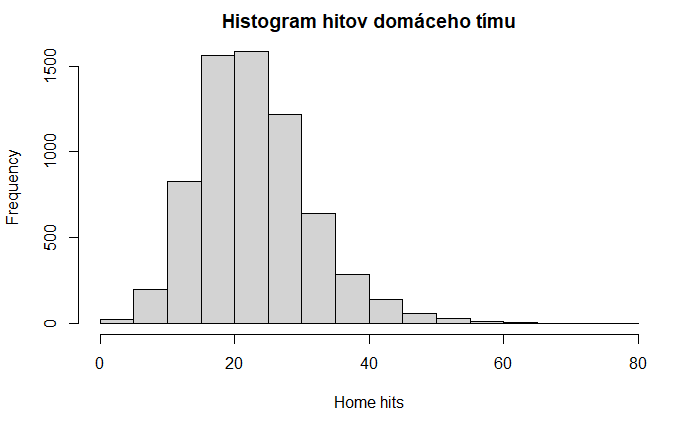

```r
hist(df$hits.home, xlab="Home hits", main="Histogram hitov domáceho tímu")
```

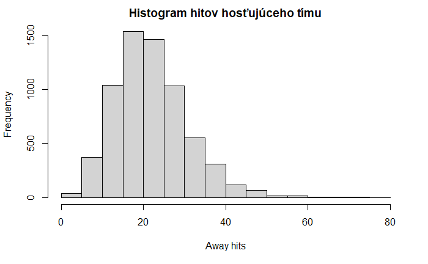

```r
hist(df$hits.away, xlab="Away hits", main="Histogram hitov hosťujúceho tímu")
```

Diagram pripomína normálne rozdelenie hodnôt, ale obsahuje niekoľko vychýlených hodnôt, ktoré mohli nastať z dôvodu dlhších zápasov, napr. predĺženia. Pre tento atribút bude vhodné vykonať Shapiro-Wilkov test normality, aby sme sa uistili, že rozdelenie normálne naozaj nebude.

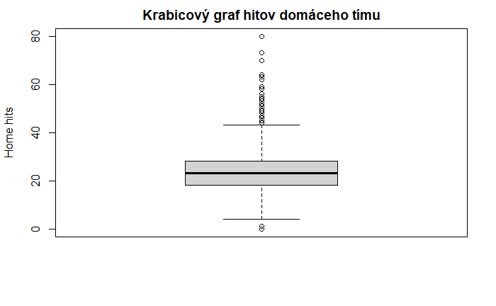

```r
boxplot(df$hits.home,  ylab="Home hits", main="Krabicový graf hitov domáceho tímu")
```